# Assignment 6

In this assignment, you'll analyze a collection of data sets from the [San Francisco Open Data Portal](http://data.sfgov.org/) and [Zillow](https://www.zillow.com/). The data sets have been stored in the SQLite database `sf_data.sqlite`, which you can [download here](http://anson.ucdavis.edu/~nulle/sf_data.sqlite). The database contains the following tables:

| Table | Description |
| --- | --- |
| `crime` | Crime reports dating back to 2010. |
| `mobile_food_locations` | List of all locations where mobile food vendors sell. |
| `mobile_food_permits` | List of all mobile food vendor permits. More details [here](https://data.sfgov.org/api/views/rqzj-sfat/files/8g2f5RV4PEk0_b24iJEtgEet9gnh_eA27GlqoOjjK4k?download=true&filename=DPW_DataDictionary_Mobil… |
| `mobile_food_schedule` | Schedules for mobile food vendors. |
| `noise` | Noise complaints dating back to August 2015. |
| `parking` | List of all parking lots. |
| `parks` | List of all parks. |
| `schools` | List of all schools. |
| `zillow` | Zillow rent and housing statistics dating back to 1996. More details [here](https://www.zillow.com/research/data/). |

The `mobile_food_` tables are explicitly connected through the `locationid` and `permit` columns. The other tables are not connected, but you may be able to connect them using dates, latitude/longitude, or postal codes.

Shapefiles for US postal codes are available [here](https://www.census.gov/geo/maps-data/data/cbf/cbf_zcta.html). These may be useful for converting latitude/longitude to postal codes.

Shapefiles for San Francisco Neighborhoods are available [here](https://data.sfgov.org/Geographic-Locations-and-Boundaries/SF-Find-Neighborhoods/pty2-tcw4).

```python
import pandas as pd
from matplotlib import pyplot as plt
import sqlalchemy as sqla
import sqlite3
from mpl_toolkits.basemap import Basemap
from shapely.geometry import Point, MultiPoint
import shapefile
import zipcode
import folium
from folium import plugins
from sklearn import preprocessing
import numpy as np
from matplotlib.patches import Circle, Wedge, Polygon
import matplotlib.cm as cm
import matplotlib.colors as colors
%matplotlib inline
plt.style.use('ggplot')
```

```python
sqlite_file = '/Users/natty/STA141B/hw6/sf_data.sqlite'
food_conn = sqla.create_engine('sqlite:///' + sqlite_file)
```

```python
query = """select "Applicant",count("locationid") as count from mobile_food_permits
    where "Applicant"!=" "
    group by "Applicant"
    order by count("locationid") desc"""
Applicant_count = pd.read_sql_query(query,food_conn)
Applicant_count.head(1)
```

|  | Applicant | count |
| --- | --- | --- |
| 0 | Roadside Rotisserie Corporation / Country Grill | 7 |

**Conclusion** :So according to the head of the result, Roadside Rotisserie Corporation/Country Grill has the most locations, as its count is 7.

**Exercise 1.2.** Ask and use the database to analyze 5 questions about San Francisco. For each question, write at least 150 words and support your answer with plots. Make a map for at least 2 of the 5 questions.

You should try to come up with some questions on your own, but these are examples of reasonable questions:

- Which parts of the city are the most and least expensive?
- Which parts of the city are the most dangerous (and at what times)?
- Are noise complaints and mobile food vendors related?
- What are the best times and places to find food trucks?
- Is there a relationship between housing prices and any of the other tables?

Please make sure to clearly state each of your questions in your submission.

* **Which parts of the city are the most and least expensive?**

```python
query = """
select "RegionName",avg("MedianSoldPricePerSqft_AllHomes") as avg from zillow where "MedianSoldPricePerSqft_AllHomes"!=' ' group by "RegionName"
order by avg("MedianSoldPricePerSqft_AllHomes")
"""
sold = pd.read_sql_query(query,food_conn)
sold.tail(1)
```

|  | RegionName | avg |
| --- | --- | --- |
| 25 | 94104 | 1336.128581 |

We see that the area near the Embarcadero is the most expensive, perhaps for real estate, particularly for the many stores and restaurants there. This is perhaps due to the fact it is heavily visited by tourists, and is near the financial district, and near many nice restaurants, as well as newly created, upscale condos and apartments. This area is also a major transportation hub, as there is the BART station, as well as the ferries near the water. In addition, this district, in addition to the financial district, is close to other popular districts, such as Chinatown, North Beach. Many people, if they live in San Francisco, want to live near good transportation. In addition, many tech companies have moved closer downtown, so their workers would like to live close to work, and this has brought the price up of this district up, as historically the most expensive neighbourhood in San Francisco has always been Pacific Heights. However, because companies do not operate in that district, and the tech industry has become a more valuable asset to the city, the companies locations have increased in value over the past several years.

```python
sold['lat'], sold['lon'] = [zipcode.isequal(str(x)).lat for x in sold.RegionName],[zipcode.isequal(str(x)).lon for x in sold.RegionName]
sold.head(1)
```

|  | RegionName | avg | lat | lon |
| --- | --- | --- | --- | --- |
| 0 | 94124 | 297.008046 | 37.73 | -122.38 |

The least expensive part of San Francisco is the Bayview district. Due to the majority of the population of this district being Black, and because of the cities history of anti-Black procedures towards its Black residents, the least expensive part of the city would be occupied primarily by Black residents, because they have been economically pushed out of all of the other districts in the city. This can be seen with the Fillmore district, as well as the Ingleside heights district, both of which have been historically predominately Black neighbourhoods, but have been pushed out by the city through gentrification practiises. In addition, the Bayview district is very isolated from the other parts of the city, and lacks major transportation options, as well as restaurants, and many grocery stores, as it is mostly warehouses, and is close to several freeways. As how Oakland has been changing in that its historic Black population has been forced out due to increasing prices to other areas, this will likely affect this district in being that it will no longer be the least expensive district in the city, as more non-Black people move into the area and cause the values of the properties to increase.

***Which parts of the city are the most dangerous (and at what times)?**

```python
query = """select avg("Lon") as 'lon', avg("Lat") as 'lat',"PdDistrict",count(*) as 'count' from crime where "PdDistrict"!=' ' group by "PdDistrict" order by count(*) """
crime = pd.read_sql_query(query,food_conn)
crime.tail(1)
```

|  | lon | lat | PdDistrict | count |
| --- | --- | --- | --- | --- |
| 9 | -122.405164 | 37.779828 | SOUTHERN | 196178 |

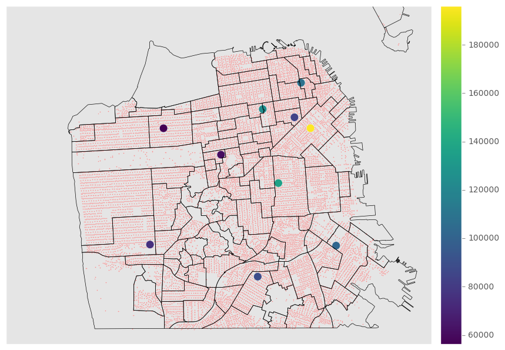

```python
query = """select "Category","Lon","Lat" from crime"""
crime_map = pd.read_sql_query(query,food_conn)

x=list(crime_map.Lon)
y=list(crime_map.Lat)

fig, ax1 = plt.subplots(figsize=(10, 8))
my_map = Basemap(resolution='i',projection='merc',llcrnrlat=37.7026, urcrnrlat=37.8236, llcrnrlon=-122.5430, urcrnrlon=-122.3503)
x1,y1=my_map(x,y)
my_map.scatter(x1,y1,s=1,c='r',marker="o",cmap=cm.cool,alpha=0.8)
my_map.readshapefile("geo_export_44af5c14-2ca2-4c06-84fd-c8c77dbdcee6", 'sanfran')

x2,y2=my_map(list(crime.lon),list(crime.lat))
my_map.scatter(x2,y2,s=100,c=np.array(crime['count']),marker="o",cmap='viridis',alpha=1)
my_map.colorbar()

plt.show()
```

```python
query = """select "PdDistrict", count(*) as count from crime where "PdDistrict" != '' group by "PdDistrict" order by count desc """
pd.read_sql_query(query,food_conn).head()
```

|  | PdDistrict | count |
| --- | --- | --- |
| 0 | SOUTHERN | 196178 |
| 1 | MISSION | 136216 |
| 2 | NORTHERN | 124365 |
| 3 | CENTRAL | 109242 |
| 4 | BAYVIEW | 101655 |

```python
query = """select "DayOfWeek", count(*) as count from crime where "PdDistrict"=="SOUTHERN" group by "DayOfWeek" order by count desc """
pd.read_sql_query(query,food_conn)
```

|  | DayOfWeek | count |
| --- | --- | --- |
| 0 | Friday | 30952 |
| 1 | Saturday | 29790 |
| 2 | Wednesday | 28394 |
| 3 | Thursday | 28150 |
| 4 | Tuesday | 26614 |
| 5 | Sunday | 26335 |
| 6 | Monday | 25943 |

Friday appears to be the day of the week with most crime activities, likely because it is the last day of the work week. In regards to that notion, more than likely crime is occurring on this day because people are going out on this day, and there are more people out on the streets, thus making crimes of opportunities more likely to happen. This means that with more people, there is a greater chance of: pick pockets, items such as purses being taken, as well as noise complaints. In addition, Friday also means that other people outside of the city will come and visit the city for eating or for doing other activities, such as going to bars or visiting clubs. Due to not knowing what the highest form of crime that is happening is, we can only suspect so much as assume that it is due to the increased population of people, likely in the downtown area.

- **Are noise complaints and mobile food vendors related?**

```python
query ="""select "Lat" as lat,"Lon" as lon from noise where lat != '' and lon != '' """
noise_loc = pd.read_sql_query(query,food_conn)

query ="""select "Latitude" as lat, "Longitude" as lon from mobile_food_locations"""
food_loc = pd.read_sql_query(query,food_conn)
```

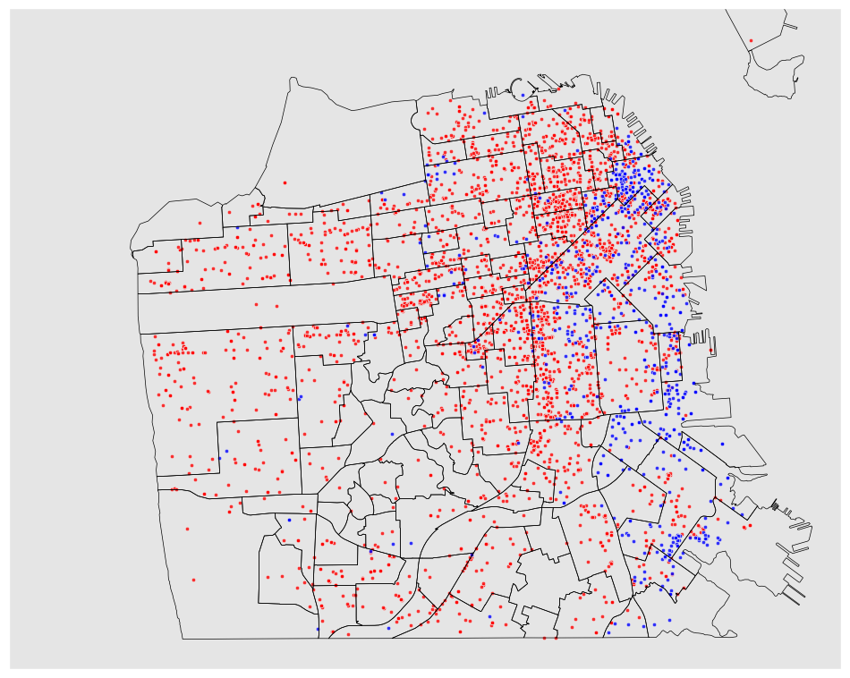

```python
fig, ax1 = plt.subplots(figsize=(12, 10))

cmap = Basemap(llcrnrlat=37.7026, urcrnrlat=37.8236, llcrnrlon=-122.5430, urcrnrlon=-122.3503,
               resolution='i',projection='merc')
cmap.readshapefile("geo_export_44af5c14-2ca2-4c06-84fd-c8c77dbdcee6", 'comarques')
x1,y1 = cmap(list(noise_loc.lon),list(noise_loc.lat))
x2,y2 = cmap(list(food_loc.lon),list(food_loc.lat))
cmap.scatter(x1,y1,s=10,c='r',marker="o",cmap=cm.jet,alpha=0.8,)
cmap.scatter(x2,y2,s=10,c='b',marker="o",cmap=cm.jet,alpha=0.8,)
```

```python
print np.mean(food_loc.lat), np.mean(noise_loc.lat)
```

```
34.8605106315 37.7695237083
```

```python
print np.mean(food_loc.lon),np.mean(noise_loc.lon)
```

```
-112.987534742 -122.427936492
```

As we see that food vendors are labeled in blue, and nosie complaints are labelled in red, we see that the majority of fod vendors are located towards the eastern part of the city, close to downtown where the majority of people who work downtown can easily venture off and find a food truck. The amount of noise complaints are scattered completely across the city, and the majority of them are being reported no where near any food trucks. For instance, there are many noise complaints happening in residential area such as the Sunset district, the Richmond district, as well as the Ingleside district. While there are some stores in these areas, there are no food trucks in these areas because they are mostly residential areas, and the food truck companies locations appear to be influenced by the highest population of workers, who will likely go out for lunch and buy from the food trucks. It is unlikely that if a food truck was operating in a residential area such as the outer sunset, that they would get a lot of customers, and would likely not be allowed to be there because of the fact it’s a residential area.

- **What are the best times and places to find food trucks?**

```python
query = """
select "Address" as address,"DayOfWeek" as weekday, "EndHour" as end, "StartHour" as start, count(*) as count from mobile_food_schedule
join mobile_food_locations on mobile_food_schedule.locationid = mobile_food_locations.locationid
join mobile_food_permits on mobile_food_schedule.permit = mobile_food_permits.permit
where "FacilityType" == 'Truck'
group by Address, weekday
order by count desc
"""
truck = pd.read_sql_query(query,food_conn)
truck.head(10)
```

|  | address | weekday | end | start | count |
| --- | --- | --- | --- | --- | --- |
| 0 | 400 HOWARD ST | Th | 14 | 11 | 8 |
| 1 | 400 HOWARD ST | Tu | 14 | 11 | 8 |
| 2 | Assessors Block /Lot | Mo | 11 | 10 | 8 |
| 3 | 400 HOWARD ST | Fr | 17 | 16 | 7 |
| 4 | 400 HOWARD ST | Mo | 17 | 16 | 7 |
| 5 | 400 HOWARD ST | We | 14 | 11 | 7 |
| 6 | 1 SANSOME ST | Fr | 15 | 11 | 4 |
| 7 | 1 SANSOME ST | Mo | 15 | 11 | 4 |
| 8 | 1 SANSOME ST | Th | 15 | 11 | 4 |
| 9 | 1 SANSOME ST | Tu | 15 | 11 | 4 |

- **Is there a relationship between housing prices and any of the other tables?**

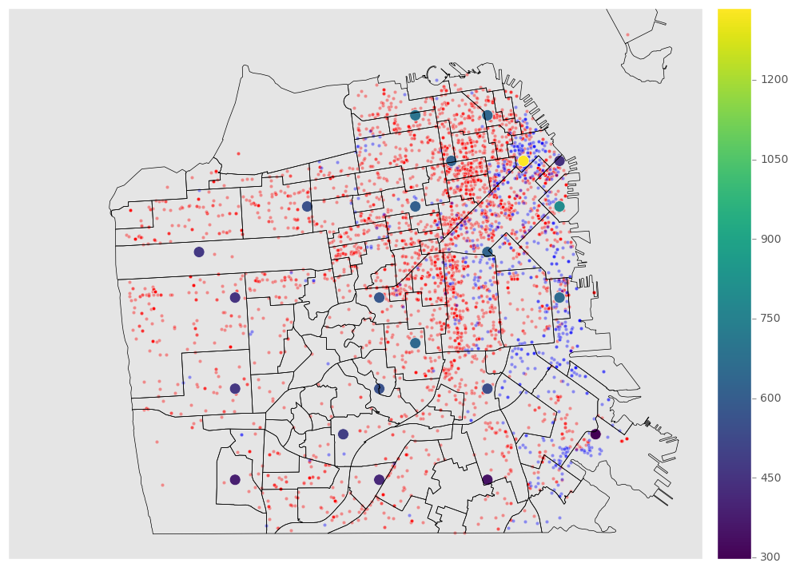

```python
fig, ax1 = plt.subplots(figsize=(12, 10))
dmap = Basemap(llcrnrlat=37.7026, urcrnrlat=37.8236, llcrnrlon=-122.5430, urcrnrlon=-122.3503,
               resolution='i',projection='merc')
dmap.readshapefile("geo_export_44af5c14-2ca2-4c06-84fd-c8c77dbdcee6", 'comarques')
x1,y1=bmap(list(sold.lon),list(sold.lat))
x2,y2 = cmap(list(noise_loc.lon),list(noise_loc.lat))
x3,y3 = cmap(list(food_loc.lon),list(food_loc.lat))
dmap.scatter(x2,y2,s=10,c='r',marker="o",cmap=cm.jet,alpha=0.4,)
dmap.scatter(x3,y3,s=10,c='b',marker="o",cmap=cm.jet,alpha=0.4,)
dmap.scatter(x1,y1,s=100,c=np.array(sold.avg),marker="o",cmap='viridis',alpha=1,)
dmap.colorbar()
```